# Model Selection & Model Performance

## 2.5 Analysis of Dense Layers

My analysis of the Dense layers was inconclusive and did not give any indication of how many dense layers better fit the overall model. The model accepts 5 Dense layers and had almost identical results with each one. I decided to use 3 dense layers as the datasize would eventually increase using Image Augmentation and increasing the number of dense layers would allow for a better convergence speed and overall training speed.

### 2.5.1 Create the Model

```python
model = Sequential()

model.add(Conv2D(16, (3,3), input_shape = X.shape[1:]))
model.add(Activation("relu"))
model.add(MaxPooling2D(pool_size=(2,2)))

model.add(Conv2D(32, (3,3)))
model.add(Activation("relu"))
model.add(MaxPooling2D(pool_size=(2,2)))

model.add(Conv2D(64, (3,3)))
model.add(Activation("relu"))
model.add(MaxPooling2D(pool_size=(2,2)))

model.add(Conv2D(128, (3,3)))
model.add(Activation("relu"))
model.add(MaxPooling2D(pool_size=(2,2)))

model.add(Flatten())

model.add(Dense(32))
model.add(Activation("relu"))

model.add(Dense(1))
model.add(Activation("sigmoid"))

model.compile(loss="binary_crossentropy",
             optimizer="Adam",
             metrics=['accuracy'])
```

### 2.5.2 Fit the Model

```python
dense_1 = model.fit(X, y, batch_size=16, epochs=50, validation_split=0.33)
```

```
Train on 334 samples, validate on 166 samples
```

### 2.5.3 Visualise the Models Performance

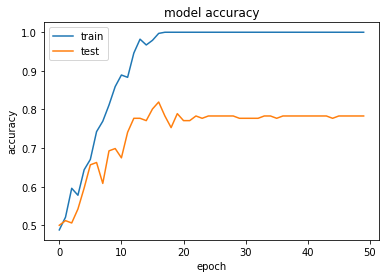

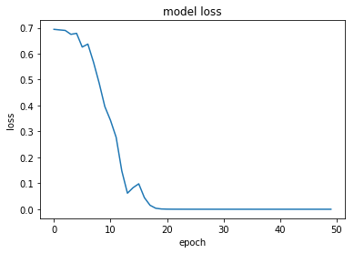

```python
plt.plot(dense_1.history['acc'])
plt.plot(dense_1.history['val_acc'])
plt.title('model accuracy')
plt.ylabel('accuracy')
plt.xlabel('epoch')
plt.legend(['train', 'test'], loc='upper left')
plt.show()

plt.plot(dense_4.history['loss'])
plt.title('model loss')
plt.ylabel('loss')
plt.xlabel('epoch')
plt.show()
```

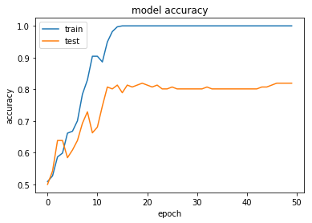

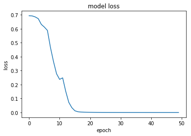

```python
plt.plot(dense_2.history['acc'])
plt.plot(dense_2.history['val_acc'])
plt.title('model accuracy')
plt.ylabel('accuracy')
plt.xlabel('epoch')
plt.legend(['train', 'test'], loc='upper left')
plt.show()

plt.plot(dense_2.history['loss'])
plt.title('model loss')
plt.ylabel('loss')
plt.xlabel('epoch')
plt.show()
```

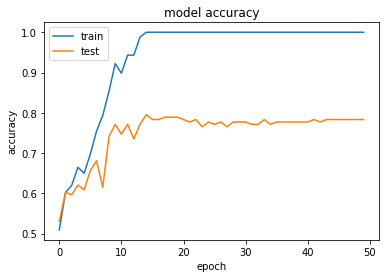

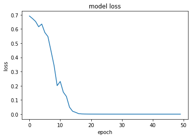

```python
plt.plot(dense_3.history['acc'])
plt.plot(dense_3.history['val_acc'])
plt.title('model accuracy')
plt.ylabel('accuracy')
plt.xlabel('epoch')
plt.legend(['train', 'test'], loc='upper left')
plt.show()

plt.plot(dense_3.history['loss'])
plt.title('model loss')
plt.ylabel('loss')
plt.xlabel('epoch')
plt.show()
```

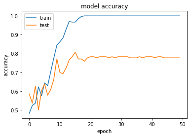

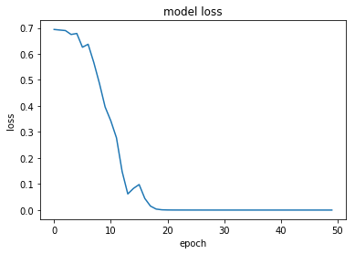

```python
plt.plot(dense_4.history['acc'])
plt.plot(dense_4.history['val_acc'])
plt.title('model accuracy')
plt.ylabel('accuracy')
plt.xlabel('epoch')
plt.legend(['train', 'test'], loc='upper left')
plt.show()

plt.plot(dense_4.history['loss'])
plt.title('model loss')
plt.ylabel('loss')
plt.xlabel('epoch')
plt.show()
```

## 2.6 Analysis of Neurons

### 2.6.1 Create the Model

```python
model = Sequential()

model.add(Conv2D(16, (3,3), input_shape = X.shape[1:]))
model.add(Activation("relu"))
model.add(MaxPooling2D(pool_size=(2,2)))

model.add(Conv2D(32, (3,3)))
model.add(Activation("relu"))
model.add(MaxPooling2D(pool_size=(2,2)))

model.add(Conv2D(64, (3,3)))
model.add(Activation("relu"))
model.add(MaxPooling2D(pool_size=(2,2)))

model.add(Conv2D(128, (3,3)))
model.add(Activation("relu"))
model.add(MaxPooling2D(pool_size=(2,2)))

model.add(Flatten())

model.add(Dense(16))
model.add(Activation("relu"))

model.add(Dense(16))
model.add(Activation("relu"))

model.add(Dense(16))
model.add(Activation("relu"))

model.add(Dense(1))
model.add(Activation("sigmoid"))

model.compile(loss="binary_crossentropy",
             optimizer="Adam",
             metrics=['accuracy'])
```

### 2.6.2 Fit the Model

```python
dense_16 = model.fit(X, y, batch_size=16, epochs=50, validation_split=0.33)
```

```
Train on 334 samples, validate on 166 samples
```

### 2.6.3 Visualise the Results

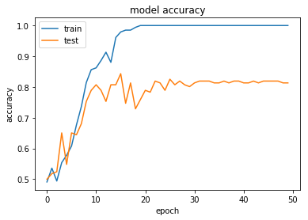

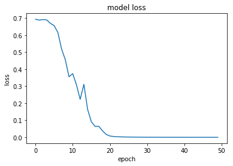

```python
plt.plot(dense_16.history['acc'])
plt.plot(dense_16.history['val_acc'])
plt.title('model accuracy')
plt.ylabel('accuracy')
plt.xlabel('epoch')
plt.legend(['train', 'test'], loc='upper left')
plt.show()

plt.plot(dense_16.history['loss'])
plt.title('model loss')
plt.ylabel('loss')
plt.xlabel('epoch')
plt.show()
```

### 2.6.4 Sub-plot the Results

Increasing the number of dense layers and the number of neurons stored in each did not give an indication of hwich parameter set was the best overall fit for the model. From the results below the ranges 32-128 where the best neuron ranges to use, because of this they will likely be used as our hyper-paramter values during the grid search stage.

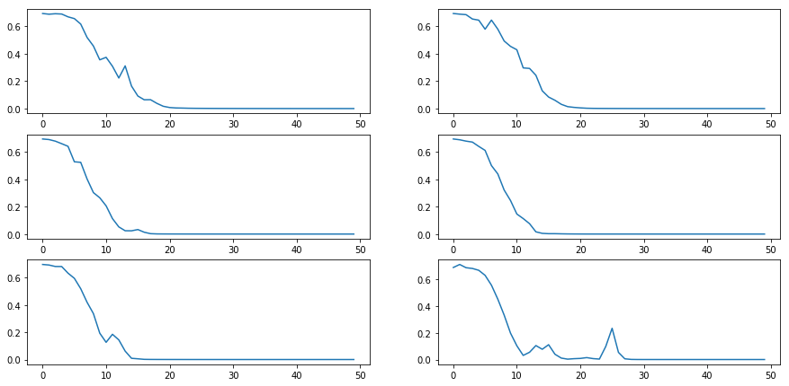

```python
fig = plt.figure(figsize=(15,15))

plt.subplot(6, 2, 1)
plt.plot(dense_16.history['loss'])

plt.subplot(6, 2, 2)
plt.plot(dense_32.history['loss'])

plt.subplot(6, 2, 3)
plt.plot(dense_64.history['loss'])

plt.subplot(6, 2, 4)
plt.plot(dense_128.history['loss'])

plt.subplot(6, 2, 5)
plt.plot(dense_256.history['loss'])

plt.subplot(6, 2, 6)
plt.plot(dense_512.history['loss'])
```

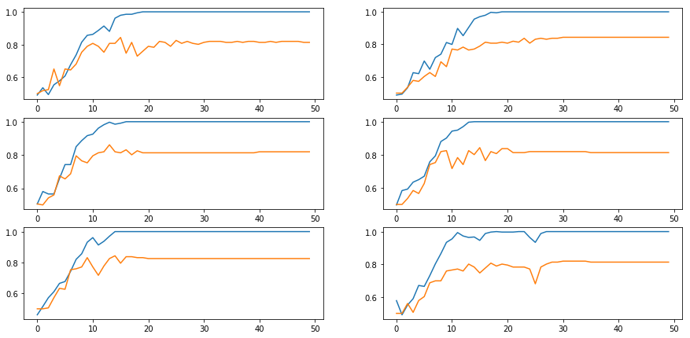

```python
fig = plt.figure(figsize=(15,15))

plt.subplot(6, 2, 1)
plt.plot(dense_16.history['acc'])
plt.plot(dense_16.history['val_acc'])

plt.subplot(6, 2, 2)
plt.plot(dense_32.history['acc'])
plt.plot(dense_32.history['val_acc'])

plt.subplot(6, 2, 3)
plt.plot(dense_64.history['acc'])
plt.plot(dense_64.history['val_acc'])

plt.subplot(6, 2, 4)
plt.plot(dense_128.history['acc'])
plt.plot(dense_128.history['val_acc'])

plt.subplot(6, 2, 5)
plt.plot(dense_256.history['acc'])
plt.plot(dense_256.history['val_acc'])

plt.subplot(6, 2, 6)
plt.plot(dense_512.history['acc'])
plt.plot(dense_512.history['val_acc'])
```

# Proposed Models

```python
model = Sequential()
```

### 3.1.2 Add the Convolutional Layers

The output image from the previous architecture was a 1 x 1 image. This is the network that will be chosen however I will now preform multiple tests on the network changing parameters such as the kernel size and the optimizer which can change the overall structure of the network. A network with a kernel K of 5 x 5 can produce 3 networks with 3, 5, 6 convolutional layers. The maximum size network with a pooling layer after each layer is 3 with an output image of 4 x 4. Using deep stacking I can create networks with 5 & 6 convolutional layers which produce output images of 3 x 3 & 2 x 2. This is the smallest size we can achieve.

```python
model.add(Conv2D(8, (5,5), input_shape = X.shape[1:]))
model.add(Activation("relu"))

model.add(Conv2D(16, (5,5)))
model.add(Activation("relu"))
model.add(MaxPooling2D(pool_size=(2,2)))

model.add(Conv2D(32, (5,5)))
model.add(Activation("relu"))

model.add(Conv2D(64, (5,5)))
model.add(Activation("relu"))
model.add(MaxPooling2D(pool_size=(2,2)))

model.add(Conv2D(128, (5,5)))
model.add(Activation("relu"))
model.add(MaxPooling2D(pool_size=(2,2)))
```

### 3.1.3 Add the Dense Layers

```python
model.add(Flatten())
model.add(Dense(128))
model.add(Activation("relu"))

model.add(Dense(64))
model.add(Activation("relu"))

model.add(Dense(32))
model.add(Activation("relu"))

model.add(Dense(1))
model.add(Activation("sigmoid"))
```

### 3.1.4 Compile the Model

```python
model.compile(loss="binary_crossentropy",
             optimizer="Adam",
             metrics=['accuracy'])
```

### 3.1.5 Fit the Model

The problem these networks present is that they do not achieve convergence.

```python
proposed_01 = model.fit(X, y, batch_size=16, epochs=50, validation_split=0.33)
```

```
Train on 334 samples, validate on 166 samples
```

### 3.1.6 Plot the Models Loss

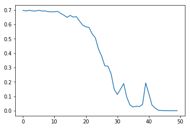

```python
plt.plot(proposed_01.history["loss"])
plt.show()
```

### 3.1.7 Further visualizations

As you can see from these results using a kernel sizxe of 5 x 5 did not have any overall effect on the model. Its loss however does not entirely coneverge with 50 epochs it would however if the epoch range was increased. The model however did benefit on terms of validation accuracy where it was common occurence for the accuracy to reach heights of 80%. A kernel size of 3 x 3 works better with the model, but the benefits of using a 5 x 5 kernel can still be acheived by using Diliation.

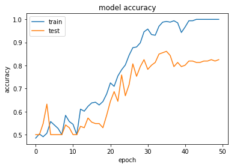

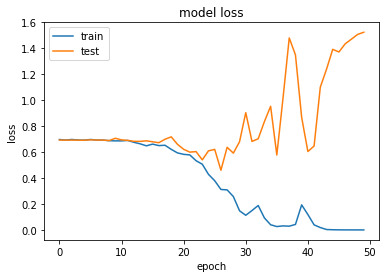

```python
plt.plot(proposed_01.history['acc'])
plt.plot(proposed_01.history['val_acc'])
plt.title('model accuracy')
plt.ylabel('accuracy')
plt.xlabel('epoch')
plt.legend(['train', 'test'], loc='upper left')
plt.show()

plt.plot(proposed_01.history['loss'])
plt.plot(proposed_01.history['val_loss'])
plt.title('model loss')
plt.ylabel('loss')
plt.xlabel('epoch')
plt.legend(['train', 'test'], loc='upper left')
plt.show()
```

## 3.2 Model 2

The models tested cannot have a stride value of 2 because it will cause an out of dimension error because our images are too small for this operation, in order to use a stride value > 1 I would need to have a network with only 1 to 2 layers ewhich as we previously saw does not produce adeqaute results. Thus, a stride value of 1 will be our default value. However this doesnt stop the use of zero padding which is a padding value of "same" in keras.

### 3.2.1 Create the Model

```python
model = Sequential()
```

### 3.2.2 Add the Convolutional Layers

```python
model.add(Conv2D(16, (3,3), padding="same", input_shape = X.shape[1:]))
model.add(Activation("relu"))
model.add(MaxPooling2D(pool_size=(2,2)))

model.add(Conv2D(32, (3,3), padding="same"))
model.add(Activation("relu"))
model.add(MaxPooling2D(pool_size=(2,2)))

model.add(Conv2D(64, (3,3), padding="same"))
model.add(Activation("relu"))
model.add(MaxPooling2D(pool_size=(2,2)))

model.add(Conv2D(128, (3,3), padding="same"))
model.add(Activation("relu"))
model.add(MaxPooling2D(pool_size=(2,2)))
```

### 3.2.3 Add the Dense Layers

```python
model.add(Flatten())
model.add(Dense(128))
model.add(Activation("relu"))

model.add(Dense(64))
model.add(Activation("relu"))

model.add(Dense(32))
model.add(Activation("relu"))

model.add(Dense(1))
model.add(Activation("sigmoid"))
```

### 3.2.4 Compile the Model

```python
model.compile(loss="binary_crossentropy",
             optimizer="Adam",
             metrics=['accuracy'])
```

### 3.2.5 Fit the Model

```python
proposed_02 = model.fit(X, y, batch_size=16, epochs=50, validation_split=0.33)
```

```
Train on 334 samples, validate on 166 samples
```

### 3.2.6 Plot the Models Loss

The model now converges nicely in epoch range of 10-20.

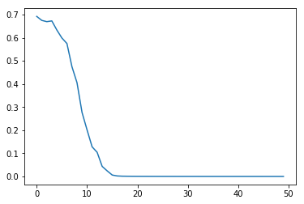

```python
plt.plot(proposed_02.history["loss"])
plt.show()
```

### 3.2.7 Further visualizations

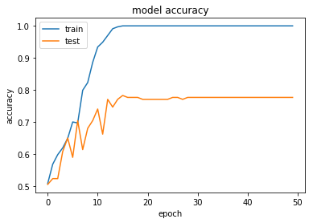

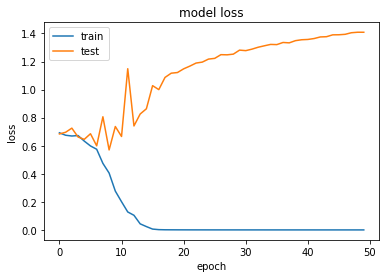

```python
plt.plot(proposed_02.history['acc'])
plt.plot(proposed_02.history['val_acc'])
plt.title('model accuracy')
plt.ylabel('accuracy')
plt.xlabel('epoch')
plt.legend(['train', 'test'], loc='upper left')
plt.show()

plt.plot(proposed_02.history['loss'])
plt.plot(proposed_02.history['val_loss'])
plt.title('model loss')
plt.ylabel('loss')
plt.xlabel('epoch')
plt.legend(['train', 'test'], loc='upper left')
plt.show()
```

## 3.3 Activation Function

### 3.3.1 TANH

#### 3.3.1.1 Create the Model

```python
model = Sequential()

model.add(Conv2D(16, (3,3), input_shape = X.shape[1:]))
model.add(Activation("tanh"))
model.add(MaxPooling2D(pool_size=(2,2)))

model.add(Conv2D(32, (3,3)))
model.add(Activation("tanh"))
model.add(MaxPooling2D(pool_size=(2,2)))

model.add(Conv2D(64, (3,3)))
model.add(Activation("tanh"))
model.add(MaxPooling2D(pool_size=(2,2)))

model.add(Conv2D(128, (3,3)))
model.add(Activation("tanh"))
model.add(MaxPooling2D(pool_size=(2,2)))

model.add(Flatten())
model.add(Dense(128))
model.add(Activation("tanh"))

model.add(Dense(64))
model.add(Activation("tanh"))

model.add(Dense(32))
model.add(Activation("tanh"))

model.add(Dense(1))
model.add(Activation("sigmoid"))

model.compile(loss="binary_crossentropy",
             optimizer="Adam",
             metrics=['accuracy'])
```

#### 3.3.1.2 FIt the Model

```python
tanh = model.fit(X, y, batch_size=16, epochs=50, validation_split=0.33)
```

```
Train on 334 samples, validate on 166 samples
```

#### 3.3.1.3 Visualise the Results

Using Tanh the model converges very fast around the 8 epoch region.

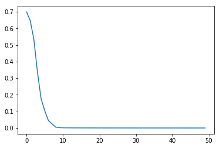

```python
plt.plot(tanh.history["loss"])
plt.show()
```

### 3.3.2 RELU

#### 3.3.2.1 Create the Model

```python
model = Sequential()

model.add(Conv2D(16, (3,3), input_shape = X.shape[1:]))
model.add(Activation("relu"))
model.add(MaxPooling2D(pool_size=(2,2)))

model.add(Conv2D(32, (3,3)))
model.add(Activation("relu"))
model.add(MaxPooling2D(pool_size=(2,2)))

model.add(Conv2D(64, (3,3)))
model.add(Activation("relu"))
model.add(MaxPooling2D(pool_size=(2,2)))

model.add(Conv2D(128, (3,3)))
model.add(Activation("relu"))
model.add(MaxPooling2D(pool_size=(2,2)))

model.add(Flatten())
model.add(Dense(128))
model.add(Activation("relu"))

model.add(Dense(64))
model.add(Activation("relu"))

model.add(Dense(32))
model.add(Activation("relu"))

model.add(Dense(1))
model.add(Activation("sigmoid"))

model.compile(loss="binary_crossentropy",
             optimizer="Adam",
             metrics=['accuracy'])
```

[output not shown]

#### 3.3.2.2 Fit the Model

```python
relu = model.fit(X, y, batch_size=16, epochs=50, validation_split=0.33)
```

```
Train on 334 samples, validate on 166 samples
WARNING:tensorflow:From C:\Users\walsh\AppData\Local\Continuum\anaconda3\envs\tf\lib\site-packages\tensorflow\python\ops\math_ops.py:3066: to_int32 (from tensorflow.python.ops.math_ops) is deprecated and will be removed in a future version.
Instructions for updating:
Use tf.cast instead.
```

#### 3.3.2.3 Visualise the Results

The model converges later then Tanh around the 20 epoch region.

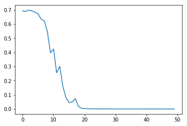

```python
plt.plot(relu.history["loss"])
plt.show()
```

# 4. Miscellanous Experiments - Convolutional Layer

## 4.1 Diliation

### 4.1.1 Apply Diliation

Adding Diliation allows my model which uses a 3 x 3 kernel to act as if it using a kernel of 5 x 5 when a diliation of 2 is applied. As with previous results the model is now using zero-padding on each convolutional layer along with a stride value of 1. This will late be changed to have padding on the pooling layers instead of the Convolutional Layers.

```python
model = Sequential()

model.add(Conv2D(16, (3,3), padding="same", dilation_rate=2, strides=1, input_shape = X.shape[1:]))
model.add(Activation("relu"))
model.add(MaxPooling2D(pool_size=(2,2)))

model.add(Conv2D(32, (3,3), padding="same", dilation_rate=2, strides=1))
model.add(Activation("relu"))
model.add(MaxPooling2D(pool_size=(2,2)))

model.add(Conv2D(64, (3,3), padding="same", dilation_rate=2, strides=1))
model.add(Activation("relu"))
model.add(MaxPooling2D(pool_size=(2,2)))

model.add(Conv2D(128, (3,3), padding="same", dilation_rate=2, strides=1,))
model.add(Activation("relu"))
model.add(MaxPooling2D(pool_size=(2,2)))

model.add(Flatten())
model.add(Dense(128))
model.add(Activation("relu"))

model.add(Dense(64))
model.add(Activation("relu"))

model.add(Dense(32))
model.add(Activation("relu"))

model.add(Dense(1))
model.add(Activation("sigmoid"))

model.compile(loss="binary_crossentropy",
             optimizer="Adam",
             metrics=['accuracy'])
```

### 4.1.2 Fit the Model

```python
exper_01 = model.fit(X, y, batch_size=16, epochs=50, validation_split=0.33)
```

```
Train on 334 samples, validate on 166 samples
```

### 4.1.3 Plot the Models Loss

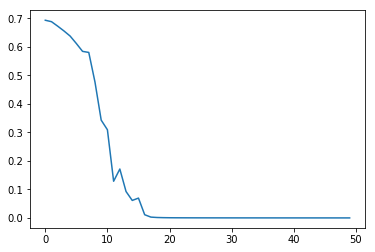

```python
plt.plot(exper_01.history["loss"])
plt.show()
```

## 4.2 Bias

Bias will be discussed further in the later regions off Generalisation, here I wanted to get a feel of how Bias effects the model and what I can expect as the projects progress increases.

### 4.2.1 Adding Bias

```python
model = Sequential()

model.add(Conv2D(16, (3,3), padding="same", dilation_rate=2, strides=1, use_bias=True, input_shape = X.shape[1:]))
model.add(Activation("relu"))
model.add(MaxPooling2D(pool_size=(2,2)))

model.add(Conv2D(32, (3,3), padding="same", dilation_rate=2, strides=1))
model.add(Activation("relu"))
model.add(MaxPooling2D(pool_size=(2,2)))

model.add(Conv2D(64, (3,3), padding="same", dilation_rate=2, strides=1))
model.add(Activation("relu"))
model.add(MaxPooling2D(pool_size=(2,2)))

model.add(Conv2D(128, (3,3), padding="same", dilation_rate=2, strides=1))
model.add(Activation("relu"))
model.add(MaxPooling2D(pool_size=(2,2)))

model.add(Flatten())
model.add(Dense(128))
model.add(Activation("relu"))

model.add(Dense(64))
model.add(Activation("relu"))

model.add(Dense(32))
model.add(Activation("relu"))

model.add(Dense(1))
model.add(Activation("sigmoid"))

model.compile(loss="binary_crossentropy",
             optimizer="Adam",
             metrics=['accuracy'])
```

### 4.2.2 Fit the Model

```python
exper_2 = model.fit(X, y, batch_size=16, epochs=50, validation_split=0.33)
```

```
Train on 334 samples, validate on 166 samples
```

### 4.2.3 Plot the Models Loss

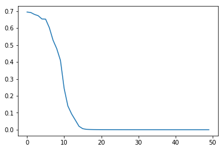

```python
plt.plot(exper_2.history["loss"])
plt.show()
```

# 5. Miscellanous Experiments - Pooling Layer

Alot of research conducted in the field of Deep-Learning places the padding on the Sub-Sampling layer instead of the Convolutional Layer. Here I instead follow these steps and place the padding on the sub-sampling layers instead of the convolutional and record the overall results.

## 5.1 Padding

### 5.1.1 Add the Padding

```python
model = Sequential()

model.add(Conv2D(16, (3,3), dilation_rate=2, strides=1, use_bias=True, input_shape = X.shape[1:]))
model.add(Activation("relu"))
model.add(MaxPooling2D(pool_size=(2,2), padding="same"))

model.add(Conv2D(32, (3,3), dilation_rate=2, strides=1))
model.add(Activation("relu"))
model.add(MaxPooling2D(pool_size=(2,2), padding="same"))

model.add(Conv2D(64, (3,3), dilation_rate=2, strides=1))
model.add(Activation("relu"))
model.add(MaxPooling2D(pool_size=(2,2), padding="same"))

model.add(Conv2D(128, (3,3), dilation_rate=2, strides=1))
model.add(Activation("relu"))
model.add(MaxPooling2D(pool_size=(2,2), padding="same"))

model.add(Flatten())
model.add(Dense(128))
model.add(Activation("relu"))

model.add(Dense(64))
model.add(Activation("relu"))

model.add(Dense(32))
model.add(Activation("relu"))

model.add(Dense(1))
model.add(Activation("sigmoid"))

model.compile(loss="binary_crossentropy",
             optimizer="Adam",
             metrics=['accuracy'])
```

### 5.1.4 Fit the Model

```python
exper_3 = model.fit(X, y, batch_size=16, epochs=50, validation_split=0.33)
```

```
Train on 334 samples, validate on 166 samples
```

### 5.1.3 Plot the Models Loss

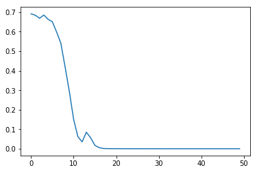

```python
plt.plot(exper_3.history["loss"])
plt.show()
```

# 6. Miscellanous Experiments - Dense Layer

## 6.1 Bias

### 6.1.1 Adding bias to the Dense Layers

```python
model = Sequential()

model.add(Conv2D(16, (3,3), dilation_rate=2, strides=1, use_bias=True, input_shape = X.shape[1:]))
model.add(Activation("relu"))
model.add(MaxPooling2D(pool_size=(2,2), padding="same"))

model.add(Conv2D(32, (3,3), dilation_rate=2, strides=1))
model.add(Activation("relu"))
model.add(MaxPooling2D(pool_size=(2,2), padding="same"))

model.add(Conv2D(64, (3,3), dilation_rate=2, strides=1))
model.add(Activation("relu"))
model.add(MaxPooling2D(pool_size=(2,2), padding="same"))

model.add(Conv2D(128, (3,3), dilation_rate=2, strides=1))
model.add(Activation("relu"))
model.add(MaxPooling2D(pool_size=(2,2), padding="same"))

model.add(Flatten())
model.add(Dense(128, use_bias=True))
model.add(Activation("relu"))

model.add(Dense(64))
model.add(Activation("relu"))

model.add(Dense(32))
model.add(Activation("relu"))

model.add(Dense(1))
model.add(Activation("sigmoid"))

model.compile(loss="binary_crossentropy",
             optimizer="Adam",
             metrics=['accuracy'])
```

### 6.1.2 Fit the Model

```python
exper_4 = model.fit(X, y, batch_size=16, epochs=50, validation_split=0.33)
```

```
Train on 334 samples, validate on 166 samples
```

### 6.1.3 Plot the Models Loss

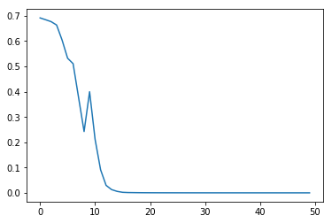

```python
plt.plot(exper_4.history["loss"])
plt.show()
```

# 7. Miscellanous Experiments - Optmizers

## 7.1 RMSPROP

### 7.1.1 Compile & Fit the Model

```python
model = Sequential()

model.add(Conv2D(16, (3,3), dilation_rate=2, strides=1, input_shape = X.shape[1:]))
model.add(Activation("relu"))
model.add(MaxPooling2D(pool_size=(2,2), padding="same"))

model.add(Conv2D(32, (3,3), dilation_rate=2, strides=1))
model.add(Activation("relu"))
model.add(MaxPooling2D(pool_size=(2,2), padding="same"))

model.add(Conv2D(64, (3,3), dilation_rate=2, strides=1))
model.add(Activation("relu"))
model.add(MaxPooling2D(pool_size=(2,2), padding="same"))

model.add(Conv2D(128, (3,3), dilation_rate=2, strides=1))
model.add(Activation("relu"))
model.add(MaxPooling2D(pool_size=(2,2), padding="same"))

model.add(Flatten())
model.add(Dense(128))
model.add(Activation("relu"))

model.add(Dense(64))
model.add(Activation("relu"))

model.add(Dense(32))
model.add(Activation("relu"))

model.add(Dense(1))
model.add(Activation("sigmoid"))

model.compile(loss="binary_crossentropy",
             optimizer="Rmsprop",
             metrics=['accuracy'])

Rmsprop = model.fit(X, y, batch_size=16, epochs=50, validation_split=0.33)
```

```
Train on 334 samples, validate on 166 samples
```

### 7.1.2 Plot the Models Loss

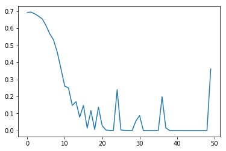

```python
plt.plot(Rmsprop.history["loss"])
plt.show()
```

## 7.2 ADAGARD

### 7.2.1 Fit the Model

```python
model = Sequential()

model.add(Conv2D(16, (3,3), dilation_rate=2, strides=1, input_shape = X.shape[1:]))
model.add(Activation("relu"))
model.add(MaxPooling2D(pool_size=(2,2), padding="same"))

model.add(Conv2D(32, (3,3), dilation_rate=2, strides=1))
model.add(Activation("relu"))
model.add(MaxPooling2D(pool_size=(2,2), padding="same"))

model.add(Conv2D(64, (3,3), dilation_rate=2, strides=1))
model.add(Activation("relu"))
model.add(MaxPooling2D(pool_size=(2,2), padding="same"))

model.add(Conv2D(128, (3,3), dilation_rate=2, strides=1))
model.add(Activation("relu"))
model.add(MaxPooling2D(pool_size=(2,2), padding="same"))

model.add(Flatten())
model.add(Dense(128))
model.add(Activation("relu"))

model.add(Dense(64))
model.add(Activation("relu"))

model.add(Dense(32))
model.add(Activation("relu"))

model.add(Dense(1))
model.add(Activation("sigmoid"))

model.compile(loss="binary_crossentropy",
             optimizer="Adagrad",
             metrics=['accuracy'])

Adagrad = model.fit(X, y, batch_size=16, epochs=50, validation_split=0.33)
```

```
Train on 334 samples, validate on 166 samples
```

### 7.2.2 Plot the Models Loss

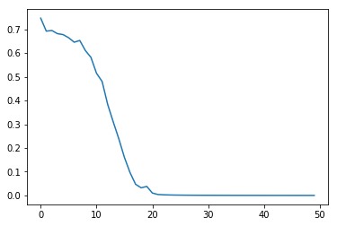

```python
plt.plot(Adagrad.history["loss"])
plt.show()
```

## 7.3 Adamax

### 7.3.1 Create the Model

```python
model = Sequential()

model.add(Conv2D(16, (3,3), dilation_rate=2, strides=1, input_shape = X.shape[1:]))
model.add(Activation("relu"))
model.add(MaxPooling2D(pool_size=(2,2), padding="same"))

model.add(Conv2D(32, (3,3), dilation_rate=2, strides=1))
model.add(Activation("relu"))
model.add(MaxPooling2D(pool_size=(2,2), padding="same"))

model.add(Conv2D(64, (3,3), dilation_rate=2, strides=1))
model.add(Activation("relu"))
model.add(MaxPooling2D(pool_size=(2,2), padding="same"))

model.add(Conv2D(128, (3,3), dilation_rate=2, strides=1))
model.add(Activation("relu"))
model.add(MaxPooling2D(pool_size=(2,2), padding="same"))

model.add(Flatten())
model.add(Dense(128))
model.add(Activation("relu"))

model.add(Dense(64))
model.add(Activation("relu"))

model.add(Dense(32))
model.add(Activation("relu"))

model.add(Dense(1))
model.add(Activation("sigmoid"))

model.compile(loss="binary_crossentropy",
             optimizer="adamax",
             metrics=['accuracy'])
```

### 7.3.2 Fit the Model

```python
Adamax = model.fit(X, y, batch_size=16, epochs=50, validation_split=0.2)
```

```
Train on 400 samples, validate on 100 samples
```

### 7.3.3 Visualise the Models Performance

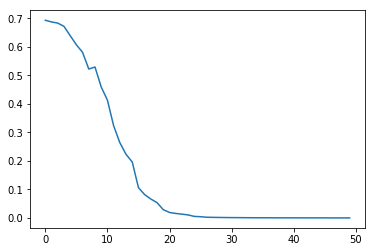

```python
plt.plot(Adamax.history["loss"])
plt.show()
```

## 7.4 SGD

### 7.4.1 Create the Model

```python
model = Sequential()

model.add(Conv2D(16, (3,3), dilation_rate=2, strides=1, input_shape = X.shape[1:]))
model.add(Activation("relu"))
model.add(MaxPooling2D(pool_size=(2,2), padding="same"))

model.add(Conv2D(32, (3,3), dilation_rate=2, strides=1))
model.add(Activation("relu"))
model.add(MaxPooling2D(pool_size=(2,2), padding="same"))

model.add(Conv2D(64, (3,3), dilation_rate=2, strides=1))
model.add(Activation("relu"))
model.add(MaxPooling2D(pool_size=(2,2), padding="same"))

model.add(Conv2D(128, (3,3), dilation_rate=2, strides=1))
model.add(Activation("relu"))
model.add(MaxPooling2D(pool_size=(2,2), padding="same"))

model.add(Flatten())
model.add(Dense(128))
model.add(Activation("relu"))

model.add(Dense(64))
model.add(Activation("relu"))

model.add(Dense(32))
model.add(Activation("relu"))

model.add(Dense(1))
model.add(Activation("sigmoid"))

model.compile(loss="binary_crossentropy",
             optimizer="sgd",
             metrics=['accuracy'])
```

### 7.4.2 Fit the Model

```python
sgd = model.fit(X, y, epochs=50, validation_split=0.33)
```

```
Train on 334 samples, validate on 166 samples
```

### 7.4.3 Visualise the Models Performance

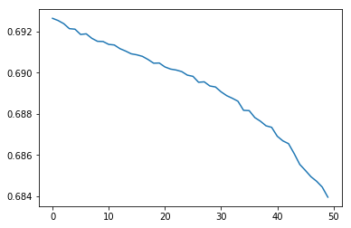

```python
plt.plot(sgd.history["loss"])
plt.show()
```

## 7.5 Adadelta

### 7.5.1 Create the Model

```python
model = Sequential()

model.add(Conv2D(16, (3,3), dilation_rate=2, strides=1, input_shape = X.shape[1:]))
model.add(Activation("relu"))
model.add(MaxPooling2D(pool_size=(2,2), padding="same"))

model.add(Conv2D(32, (3,3), dilation_rate=2, strides=1))
model.add(Activation("relu"))
model.add(MaxPooling2D(pool_size=(2,2), padding="same"))

model.add(Conv2D(64, (3,3), dilation_rate=2, strides=1))
model.add(Activation("relu"))
model.add(MaxPooling2D(pool_size=(2,2), padding="same"))

model.add(Conv2D(128, (3,3), dilation_rate=2, strides=1))
model.add(Activation("relu"))
model.add(MaxPooling2D(pool_size=(2,2), padding="same"))

model.add(Flatten())
model.add(Dense(128))
model.add(Activation("relu"))

model.add(Dense(64))
model.add(Activation("relu"))

model.add(Dense(32))
model.add(Activation("relu"))

model.add(Dense(1))
model.add(Activation("sigmoid"))

model.compile(loss="binary_crossentropy",
             optimizer="adadelta",
             metrics=['accuracy'])
```

### 7.5.2 Fit the Model

```python
adadelta = model.fit(X, y, batch_size=16, epochs=50, validation_split=0.33)
```

```
Train on 334 samples, validate on 166 samples
```

### 7.5.3 Visualise the Models Performance

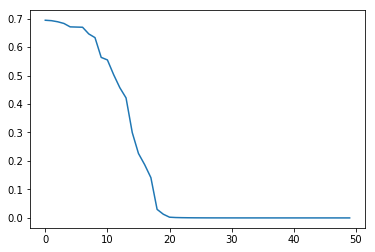

```python
plt.plot(adadelta.history["loss"])
plt.show()
```

## 7.6 Nadam

### 7.6.1 Create the Model

```python
model = Sequential()

model.add(Conv2D(16, (3,3), dilation_rate=2, strides=1, input_shape = X.shape[1:]))
model.add(Activation("relu"))
model.add(MaxPooling2D(pool_size=(2,2), padding="same"))

model.add(Conv2D(32, (3,3), dilation_rate=2, strides=1))
model.add(Activation("relu"))
model.add(MaxPooling2D(pool_size=(2,2), padding="same"))

model.add(Conv2D(64, (3,3), dilation_rate=2, strides=1))
model.add(Activation("relu"))
model.add(MaxPooling2D(pool_size=(2,2), padding="same"))

model.add(Conv2D(128, (3,3), dilation_rate=2, strides=1))
model.add(Activation("relu"))
model.add(MaxPooling2D(pool_size=(2,2), padding="same"))

model.add(Flatten())
model.add(Dense(128))
model.add(Activation("relu"))

model.add(Dense(64))
model.add(Activation("relu"))

model.add(Dense(32))
model.add(Activation("relu"))

model.add(Dense(1))
model.add(Activation("sigmoid"))

model.compile(loss="binary_crossentropy",
             optimizer="nadam",
             metrics=['accuracy'])
```

### 7.6.2 Fit the Model

```python
nadam = model.fit(X, y, batch_size=16, epochs=50, validation_split=0.33)
```

```
Train on 334 samples, validate on 166 samples
```

### 7.6.3 Visualise the Models Performance

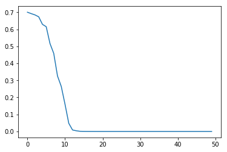

```python
plt.plot(nadam.history["loss"])
plt.show()
```

# 8. Dropout - Dense Layers

Here I investigate the usage of Dropout on the Model I currently have. However, this process be investigated deeper in the later stage of Generalisation once I have recorded my best preforming model from Grid Search.

## 8.1 Adding Dropout 0.1

### 8.1.1 Create the Model

```python
model = Sequential()
```

### 8.1.2 Add the Convolutional Layers

```python
model.add(Conv2D(16, (3,3), dilation_rate=2, strides=1, input_shape = X.shape[1:]))
model.add(Activation("relu"))
model.add(MaxPooling2D(pool_size=(2,2), padding="same"))

model.add(Conv2D(32, (3,3), dilation_rate=2, strides=1))
model.add(Activation("relu"))
model.add(MaxPooling2D(pool_size=(2,2), padding="same"))

model.add(Conv2D(64, (3,3), dilation_rate=2, strides=1))
model.add(Activation("relu"))
model.add(MaxPooling2D(pool_size=(2,2), padding="same"))

model.add(Conv2D(128, (3,3), dilation_rate=2, strides=1))
model.add(Activation("relu"))
model.add(MaxPooling2D(pool_size=(2,2), padding="same"))
```

### 8.1.3 Add the Dense Layers

```python
model.add(Flatten())
model.add(Dense(128))
model.add(Activation("relu"))
model.add(Dropout(0.1))

model.add(Dense(64))
model.add(Activation("relu"))
model.add(Dropout(0.1))

model.add(Dense(32))
model.add(Activation("relu"))
model.add(Dropout(0.1))

model.add(Dense(1))
model.add(Activation("sigmoid"))
```

### 8.1.4 Compile the Model

```python
model.compile(loss="binary_crossentropy",
             optimizer="Adam",
             metrics=['accuracy'])
```

### 8.1.5 Fit the Model

```python
drop_1 = model.fit(X, y, batch_size=16, epochs=50, validation_split=0.33)
```

```
Train on 334 samples, validate on 166 samples
```

### 8.1.6 Visualise the Models Performance

No overall improvemnet to the problem of overfitting in the dataset.

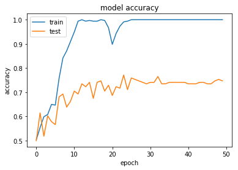

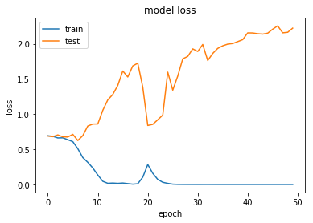

```python
plt.plot(drop_1.history['acc'])
plt.plot(drop_1.history['val_acc'])
plt.title('model accuracy')
plt.ylabel('accuracy')
plt.xlabel('epoch')
plt.legend(['train', 'test'], loc='upper left')
plt.show()

plt.plot(drop_1.history['loss'])
plt.plot(drop_1.history['val_loss'])
plt.title('model loss')
plt.ylabel('loss')
plt.xlabel('epoch')
plt.legend(['train', 'test'], loc='upper left')
plt.show()
```

## 8.2 Adding Dropout 0.2

### 8.2.1 Adding the Dense Layers

```python
model = Sequential()

model.add(Conv2D(16, (3,3), dilation_rate=2, strides=1, input_shape = X.shape[1:]))
model.add(Activation("relu"))
model.add(MaxPooling2D(pool_size=(2,2), padding="same"))

model.add(Conv2D(32, (3,3), dilation_rate=2, strides=1))
model.add(Activation("relu"))
model.add(MaxPooling2D(pool_size=(2,2), padding="same"))

model.add(Conv2D(64, (3,3), dilation_rate=2, strides=1))
model.add(Activation("relu"))
model.add(MaxPooling2D(pool_size=(2,2), padding="same"))

model.add(Conv2D(128, (3,3), dilation_rate=2, strides=1))
model.add(Activation("relu"))
model.add(MaxPooling2D(pool_size=(2,2), padding="same"))

model.add(Flatten())
model.add(Dense(128))
model.add(Activation("relu"))
model.add(Dropout(0.2))

model.add(Dense(64))
model.add(Activation("relu"))
model.add(Dropout(0.2))

model.add(Dense(32))
model.add(Activation("relu"))
model.add(Dropout(0.2))

model.add(Dense(1))
model.add(Activation("sigmoid"))

model.compile(loss="binary_crossentropy",
             optimizer="Adam",
             metrics=['accuracy'])
```

### 8.2.2 Fit the Model

```python
drop_2 = model.fit(X, y, batch_size=16, epochs=50, validation_split=0.33)
```

```
Train on 334 samples, validate on 166 samples
```

### 8.2.3 Plot the Models Performance

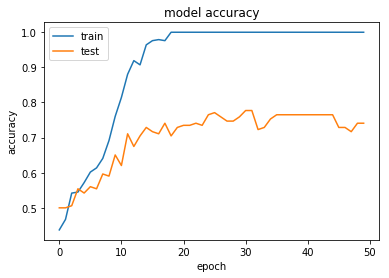

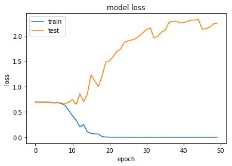

```python
plt.plot(drop_2.history['acc'])
plt.plot(drop_2.history['val_acc'])
plt.title('model accuracy')
plt.ylabel('accuracy')
plt.xlabel('epoch')
plt.legend(['train', 'test'], loc='upper left')
plt.show()

plt.plot(drop_2.history['loss'])
plt.plot(drop_2.history['val_loss'])
plt.title('model loss')
plt.ylabel('loss')
plt.xlabel('epoch')
plt.legend(['train', 'test'], loc='upper left')
plt.show()
```

## 8.3 Adding Dropout 0.3

### 8.3.1 Adding the Dense Layers

```python
model = Sequential()

model.add(Conv2D(16, (3,3), dilation_rate=2, strides=1, input_shape = X.shape[1:]))
model.add(Activation("relu"))
model.add(MaxPooling2D(pool_size=(2,2), padding="same"))

model.add(Conv2D(32, (3,3), dilation_rate=2, strides=1))
model.add(Activation("relu"))
model.add(MaxPooling2D(pool_size=(2,2), padding="same"))

model.add(Conv2D(64, (3,3), dilation_rate=2, strides=1))
model.add(Activation("relu"))
model.add(MaxPooling2D(pool_size=(2,2), padding="same"))

model.add(Conv2D(128, (3,3), dilation_rate=2, strides=1))
model.add(Activation("relu"))
model.add(MaxPooling2D(pool_size=(2,2), padding="same"))

model.add(Flatten())
model.add(Dense(128))
model.add(Activation("relu"))
model.add(Dropout(0.3))

model.add(Dense(64))
model.add(Activation("relu"))
model.add(Dropout(0.3))

model.add(Dense(32))
model.add(Activation("relu"))
model.add(Dropout(0.3))

model.add(Dense(1))
model.add(Activation("sigmoid"))

model.compile(loss="binary_crossentropy",
             optimizer="Adam",
             metrics=['accuracy'])
```

### 8.3.2 Fit the Model

```python
drop_3 = model.fit(X, y, batch_size=16, epochs=50, validation_split=0.33)
```

```
Train on 334 samples, validate on 166 samples
```

### 8.3.3 Plot the Models Performance

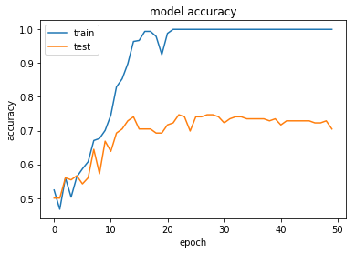

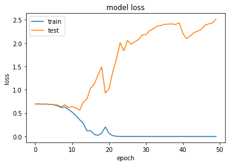

```python
plt.plot(drop_3.history['acc'])
plt.plot(drop_3.history['val_acc'])
plt.title('model accuracy')
plt.ylabel('accuracy')
plt.xlabel('epoch')
plt.legend(['train', 'test'], loc='upper left')
plt.show()

plt.plot(drop_3.history['loss'])
plt.plot(drop_3.history['val_loss'])
plt.title('model loss')
plt.ylabel('loss')
plt.xlabel('epoch')
plt.legend(['train', 'test'], loc='upper left')
plt.show()
```

## 8.4 Adding Dropout 0.4

### 8.4.1 Add the Dense Layers

```python
model = Sequential()

model.add(Conv2D(16, (3,3), dilation_rate=2, strides=1, input_shape = X.shape[1:]))
model.add(Activation("relu"))
model.add(MaxPooling2D(pool_size=(2,2), padding="same"))

model.add(Conv2D(32, (3,3), dilation_rate=2, strides=1))
model.add(Activation("relu"))
model.add(MaxPooling2D(pool_size=(2,2), padding="same"))

model.add(Conv2D(64, (3,3), dilation_rate=2, strides=1))
model.add(Activation("relu"))
model.add(MaxPooling2D(pool_size=(2,2), padding="same"))

model.add(Conv2D(128, (3,3), dilation_rate=2, strides=1))
model.add(Activation("relu"))
model.add(MaxPooling2D(pool_size=(2,2), padding="same"))

model.add(Flatten())
model.add(Dense(128))
model.add(Activation("relu"))
model.add(Dropout(0.4))

model.add(Dense(64))
model.add(Activation("relu"))
model.add(Dropout(0.4))

model.add(Dense(32))
model.add(Activation("relu"))
model.add(Dropout(0.4))

model.add(Dense(1))
model.add(Activation("sigmoid"))

model.compile(loss="binary_crossentropy",
             optimizer="Adam",
             metrics=['accuracy'])
```

### 8.4.2 Fit the Model

```python
drop_4 = model.fit(X, y, batch_size=16, epochs=50, validation_split=0.33)
```

```
Train on 334 samples, validate on 166 samples
```

### 8.4.3 Plot the Models Performance

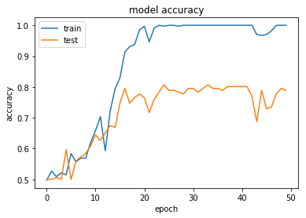

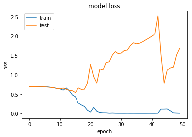

```python
plt.plot(drop_4.history['acc'])
plt.plot(drop_4.history['val_acc'])
plt.title('model accuracy')
plt.ylabel('accuracy')
plt.xlabel('epoch')
plt.legend(['train', 'test'], loc='upper left')
plt.show()

plt.plot(drop_4.history['loss'])
plt.plot(drop_4.history['val_loss'])
plt.title('model loss')
plt.ylabel('loss')
plt.xlabel('epoch')
plt.legend(['train', 'test'], loc='upper left')
plt.show()
```

## 8.5 Adding Dropout 0.5

### 8.5.1 Adding the Dense Layers

```python
model = Sequential()

model.add(Conv2D(16, (3,3), dilation_rate=2, strides=1, input_shape = X.shape[1:]))
model.add(Activation("relu"))
model.add(MaxPooling2D(pool_size=(2,2), padding="same"))

model.add(Conv2D(32, (3,3), dilation_rate=2, strides=1))
model.add(Activation("relu"))
model.add(MaxPooling2D(pool_size=(2,2), padding="same"))

model.add(Conv2D(64, (3,3), dilation_rate=2, strides=1))
model.add(Activation("relu"))
model.add(MaxPooling2D(pool_size=(2,2), padding="same"))

model.add(Conv2D(128, (3,3), dilation_rate=2, strides=1))
model.add(Activation("relu"))
model.add(MaxPooling2D(pool_size=(2,2), padding="same"))

model.add(Flatten())
model.add(Dense(128))
model.add(Activation("relu"))
model.add(Dropout(0.5))

model.add(Dense(64))
model.add(Activation("relu"))
model.add(Dropout(0.5))

model.add(Dense(32))
model.add(Activation("relu"))
model.add(Dropout(0.5))

model.add(Dense(1))
model.add(Activation("sigmoid"))

model.compile(loss="binary_crossentropy",
             optimizer="Adam",
             metrics=['accuracy'])
```

### 8.5.2 Fit the Model

```python
drop_5 = model.fit(X, y, batch_size=16, epochs=50, validation_split=0.33)
```

```
Train on 334 samples, validate on 166 samples
```

### 8.5.3 Plot the Models Performance

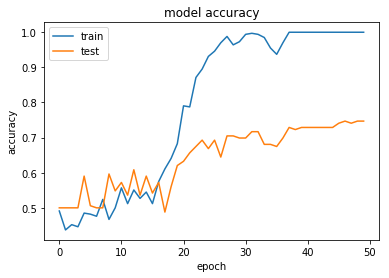

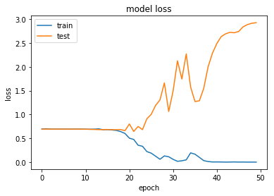

```python
plt.plot(drop_5.history['acc'])
plt.plot(drop_5.history['val_acc'])
plt.title('model accuracy')
plt.ylabel('accuracy')
plt.xlabel('epoch')
plt.legend(['train', 'test'], loc='upper left')
plt.show()

plt.plot(drop_5.history['loss'])
plt.plot(drop_5.history['val_loss'])
plt.title('model loss')
plt.ylabel('loss')
plt.xlabel('epoch')
plt.legend(['train', 'test'], loc='upper left')
plt.show()
```

# 9. Dropout - Convolutional Layer

## 9.1 Adding Dropout 0.2

### 9.1.1 Creating the Model

```python
model = Sequential()
```

### 9.1.2 Adding the Convolutional Layers

```python
model.add(Conv2D(16, (3,3), dilation_rate=2, strides=1, use_bias=True, input_shape = X.shape[1:]))
model.add(Activation("relu"))
model.add(MaxPooling2D(pool_size=(2,2), padding="same"))
model.add(Dropout(0.2))

model.add(Conv2D(32, (3,3), dilation_rate=2, strides=1))
model.add(Activation("relu"))
model.add(MaxPooling2D(pool_size=(2,2), padding="same"))
model.add(Dropout(0.2))

model.add(Conv2D(64, (3,3), dilation_rate=2, strides=1))
model.add(Activation("relu"))
model.add(MaxPooling2D(pool_size=(2,2), padding="same"))
model.add(Dropout(0.2))

model.add(Conv2D(128, (3,3), dilation_rate=2, strides=1))
model.add(Activation("relu"))
model.add(MaxPooling2D(pool_size=(2,2), padding="same"))
model.add(Dropout(0.2))
```

### 9.1.2 Add the Dense Layers

```python
model.add(Flatten())

model.add(Dense(128))
model.add(Activation("relu"))
model.add(Dropout(0.2))

model.add(Dense(64))
model.add(Activation("relu"))
model.add(Dropout(0.2))

model.add(Dense(32))
model.add(Activation("relu"))
model.add(Dropout(0.2))

model.add(Dense(1))
model.add(Activation("sigmoid"))
```

### 9.1.3 Compile the Model

```python
model.compile(loss="binary_crossentropy",
             optimizer="Adam",
             metrics=['accuracy'])
```

### 9.1.4 Fit the Model

```python
conv_01 = model.fit(X, y, batch_size=16, epochs=50, validation_split=0.33)
```

```
Train on 334 samples, validate on 166 samples
```

### 9.1.5 Plot the Models Performance

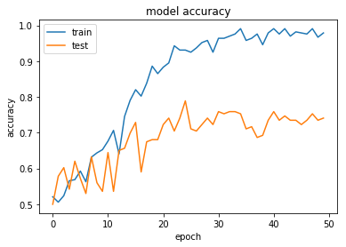

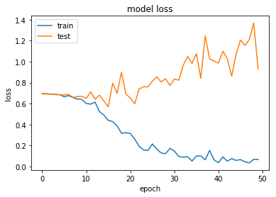

```python
plt.plot(conv_01.history['acc'])
plt.plot(conv_01.history['val_acc'])
plt.title('model accuracy')
plt.ylabel('accuracy')
plt.xlabel('epoch')
plt.legend(['train', 'test'], loc='upper left')
plt.show()

plt.plot(conv_01.history['loss'])
plt.plot(conv_01.history['val_loss'])
plt.title('model loss')
plt.ylabel('loss')
plt.xlabel('epoch')
plt.legend(['train', 'test'], loc='upper left')
plt.show()
```

## 9.2 Adding Dropout 0.3

### 9.2.1 Adding the Convolutional Layers

```python
model = Sequential()

model.add(Conv2D(16, (3,3), dilation_rate=2, strides=1, input_shape = X.shape[1:]))
model.add(Activation("relu"))
model.add(MaxPooling2D(pool_size=(2,2), padding="same"))
model.add(Dropout(0.3))

model.add(Conv2D(32, (3,3), dilation_rate=2, strides=1))
model.add(Activation("relu"))
model.add(MaxPooling2D(pool_size=(2,2), padding="same"))
model.add(Dropout(0.3))

model.add(Conv2D(64, (3,3), dilation_rate=2, strides=1))
model.add(Activation("relu"))
model.add(MaxPooling2D(pool_size=(2,2), padding="same"))
model.add(Dropout(0.3))

model.add(Conv2D(128, (3,3), dilation_rate=2, strides=1))
model.add(Activation("relu"))
model.add(MaxPooling2D(pool_size=(2,2), padding="same"))
model.add(Dropout(0.3))

model.add(Flatten())
model.add(Dense(128))
model.add(Activation("relu"))
model.add(Dropout(0.2))

model.add(Dense(64))
model.add(Activation("relu"))
model.add(Dropout(0.2))

model.add(Dense(32))
model.add(Activation("relu"))
model.add(Dropout(0.2))

model.add(Dense(1))
model.add(Activation("sigmoid"))

model.compile(loss="binary_crossentropy",
             optimizer="Adam",
             metrics=['accuracy'])
```

### 9.2.2 Fit the Model

```python
conv_02 = model.fit(X, y, batch_size=16, epochs=50, validation_split=0.33)
```

```
Train on 334 samples, validate on 166 samples
```

### 9.2.3 Plot the Models Performance

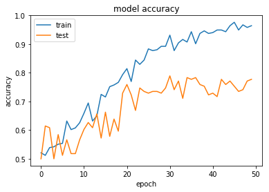

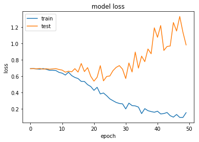

```python
plt.plot(conv_02.history['acc'])
plt.plot(conv_02.history['val_acc'])
plt.title('model accuracy')
plt.ylabel('accuracy')
plt.xlabel('epoch')
plt.legend(['train', 'test'], loc='upper left')
plt.show()

plt.plot(conv_02.history['loss'])
plt.plot(conv_02.history['val_loss'])
plt.title('model loss')
plt.ylabel('loss')
plt.xlabel('epoch')
plt.legend(['train', 'test'], loc='upper left')
plt.show()
```

# 10. Learning Rate & Decay

The Learning rate can control how fast the models can converge. At the moemnt the model is using the default value for the learning rate which was provided by keras. Here in this section I ran the model through a number of values for the learning rate and recorded the best result. The two best preforming values for the learning rate where both 0.01 and 0.001 these values will be used during grid search to determine the best preforming model. Although to note 0.01 preformed very poorly using the optimizer ADAM but preformed much better using ADAMAX this is why this value was included over the others.

## 10.1 Learning Rate 0.01

### 10.1.1 Create the Model

```python
model = Sequential()
```

### 10.1.2 Add the Convolutional Layers

```python
model.add(Conv2D(16, (3,3), dilation_rate=2, strides=1, input_shape = X.shape[1:]))
model.add(Activation("relu"))
model.add(MaxPooling2D(pool_size=(2,2), padding="same"))

model.add(Conv2D(32, (3,3), dilation_rate=2, strides=1))
model.add(Activation("relu"))
model.add(MaxPooling2D(pool_size=(2,2), padding="same"))

model.add(Conv2D(64, (3,3), dilation_rate=2, strides=1))
model.add(Activation("relu"))
model.add(MaxPooling2D(pool_size=(2,2), padding="same"))

model.add(Conv2D(128, (3,3), dilation_rate=2, strides=1))
model.add(Activation("relu"))
model.add(MaxPooling2D(pool_size=(2,2), padding="same"))
```

### 10.1.3 Add the Dense Layers

```python
model.add(Flatten())
model.add(Dense(128))
model.add(Activation("relu"))

model.add(Dense(64))
model.add(Activation("relu"))

model.add(Dense(32))
model.add(Activation("relu"))

model.add(Dense(1))
model.add(Activation("sigmoid"))
```

### 10.1.3 Compile the Model with Optimizer

```python
optimizer = Adam(lr=0.01)

model.compile(loss="binary_crossentropy",
             optimizer=optimizer,
             metrics=['accuracy'])
```

### 10.1.4 Fit the Model

```python
_01 = model.fit(X, y, batch_size=16, epochs=50, validation_split=0.33)
```

```
Train on 334 samples, validate on 166 samples
```

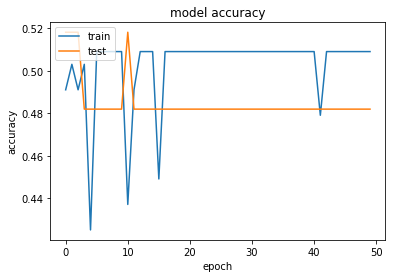

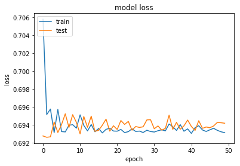

```python
plt.plot(_01.history['acc'])
plt.plot(_01.history['val_acc'])
plt.title('model accuracy')
plt.ylabel('accuracy')
plt.xlabel('epoch')
plt.legend(['train', 'test'], loc='upper left')
plt.show()

plt.plot(_01.history['loss'])
plt.plot(_01.history['val_loss'])
plt.title('model loss')
plt.ylabel('loss')
plt.xlabel('epoch')
plt.legend(['train', 'test'], loc='upper left')
plt.show()
```

### 10.1.5 Visualise the Models Loss

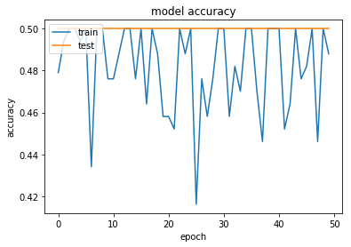

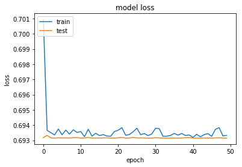

```python
plt.plot(lr_01.history['acc'])
plt.plot(lr_01.history['val_acc'])
plt.title('model accuracy')
plt.ylabel('accuracy')
plt.xlabel('epoch')
plt.legend(['train', 'test'], loc='upper left')
plt.show()

plt.plot(lr_01.history['loss'])
plt.plot(lr_01.history['val_loss'])
plt.title('model loss')
plt.ylabel('loss')
plt.xlabel('epoch')
plt.legend(['train', 'test'], loc='upper left')
plt.show()
```

## 10.2 Learning Rate 0.001

### 10.2.1 Visualise the Models Performance

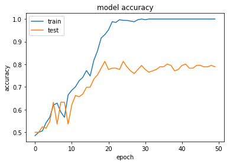

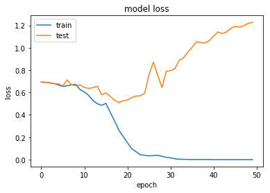

```python
plt.plot(lr_001.history['acc'])
plt.plot(lr_001.history['val_acc'])
plt.title('model accuracy')
plt.ylabel('accuracy')
plt.xlabel('epoch')
plt.legend(['train', 'test'], loc='upper left')
plt.show()

plt.plot(lr_001.history['loss'])
plt.plot(lr_001.history['val_loss'])
plt.title('model loss')
plt.ylabel('loss')
plt.xlabel('epoch')
plt.legend(['train', 'test'], loc='upper left')
plt.show()
```

## 10.3 Learning Rate 0.0001

### 10.3.1 Visualise the Models Performance

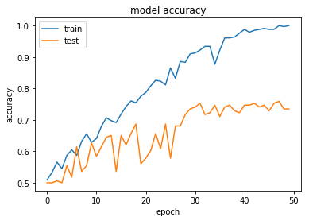

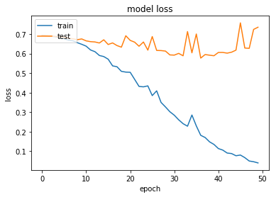

```python
plt.plot(lr_0001.history['acc'])
plt.plot(lr_0001.history['val_acc'])
plt.title('model accuracy')
plt.ylabel('accuracy')
plt.xlabel('epoch')
plt.legend(['train', 'test'], loc='upper left')
plt.show()

plt.plot(lr_0001.history['loss'])
plt.plot(lr_0001.history['val_loss'])
plt.title('model loss')
plt.ylabel('loss')
plt.xlabel('epoch')
plt.legend(['train', 'test'], loc='upper left')
plt.show()
```

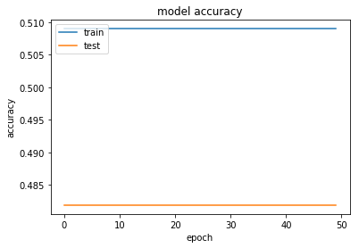

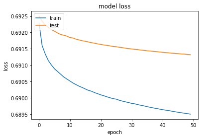

```python
plt.plot(lr_1e.history['acc'])
plt.plot(lr_1e.history['val_acc'])
plt.title('model accuracy')
plt.ylabel('accuracy')
plt.xlabel('epoch')
plt.legend(['train', 'test'], loc='upper left')
plt.show()

plt.plot(lr_1e.history['loss'])
plt.plot(lr_1e.history['val_loss'])
plt.title('model loss')
plt.ylabel('loss')
plt.xlabel('epoch')
plt.legend(['train', 'test'], loc='upper left')
plt.show()
```

## 10.6 Decay 0.1 - 0.9

The value of decay will gradully decrease the learning rate over a certian amount epochs. The value of decay was tested to investigate how it would preform on the model I created. The values used where from 0-5 which produced reasonable results, a final test using an extreme value of 0.9 was used to understand how it would affect the model. The two best recorded values for decay where both 0.0 and a value of 0.1 which will be used during grid search.

### 10.6.1 Create the Model

```python
model = Sequential()
```

### 10.6.2 Compile the Model

```python
model.add(Conv2D(16, (3,3), dilation_rate=2, strides=1, input_shape = X.shape[1:]))
model.add(Activation("relu"))
model.add(MaxPooling2D(pool_size=(2,2), padding="same"))

model.add(Conv2D(32, (3,3), dilation_rate=2, strides=1))
model.add(Activation("relu"))
model.add(MaxPooling2D(pool_size=(2,2), padding="same"))

model.add(Conv2D(64, (3,3), dilation_rate=2, strides=1))
model.add(Activation("relu"))
model.add(MaxPooling2D(pool_size=(2,2), padding="same"))

model.add(Conv2D(128, (3,3), dilation_rate=2, strides=1))
model.add(Activation("relu"))
model.add(MaxPooling2D(pool_size=(2,2), padding="same"))

model.add(Flatten())
model.add(Dense(128))
model.add(Activation("relu"))

model.add(Dense(64))
model.add(Activation("relu"))

model.add(Dense(32))
model.add(Activation("relu"))

model.add(Dense(1))
model.add(Activation("sigmoid"))

optimizer = Adam(decay=0.1)

model.compile(loss="binary_crossentropy",
             optimizer=optimizer,
             metrics=['accuracy'])
```

### 10.6.3 Fit the Model

```python
decay_001 = model.fit(X, y, batch_size=16, epochs=50, validation_split=0.33)
```

```
Train on 334 samples, validate on 166 samples
```

### 10.6.4 Visualisation - 0.1

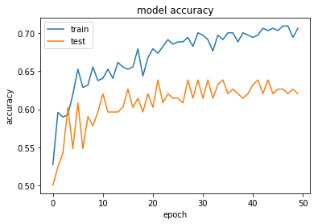

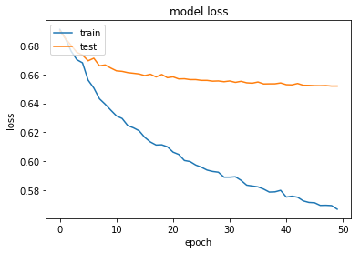

```python
plt.plot(decay_01.history['acc'])
plt.plot(decay_01.history['val_acc'])
plt.title('model accuracy')
plt.ylabel('accuracy')
plt.xlabel('epoch')
plt.legend(['train', 'test'], loc='upper left')
plt.show()

plt.plot(decay_01.history['loss'])
plt.plot(decay_01.history['val_loss'])
plt.title('model loss')
plt.ylabel('loss')
plt.xlabel('epoch')
plt.legend(['train', 'test'], loc='upper left')
plt.show()
```

### 10.6.5 Visualisation - 0.2

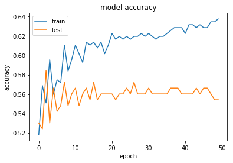

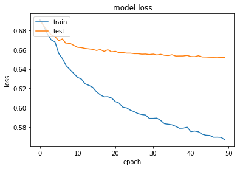

```python
plt.plot(decay_02.history['acc'])
plt.plot(decay_02.history['val_acc'])
plt.title('model accuracy')
plt.ylabel('accuracy')
plt.xlabel('epoch')
plt.legend(['train', 'test'], loc='upper left')
plt.show()

plt.plot(decay_01.history['loss'])
plt.plot(decay_01.history['val_loss'])
plt.title('model loss')
plt.ylabel('loss')
plt.xlabel('epoch')
plt.legend(['train', 'test'], loc='upper left')
plt.show()
```